# Analisi Preliminare degli Item

Esercitazione pratica e richiami alla teoria

Autore/Autrice

Margherita Calderan

Data di Pubblicazione

22 aprile 2026

# 1 Test di prestazione tipica: il Big Five

Per gli esempi che seguono utilizziamo il file `dataB.csv`, che contiene le risposte al questionario di personalità **Big Five** (test di prestazione tipica) somministrato a 19.709 partecipanti online. Gli item sono stati valutati su una scala a cinque punti (1 = *Completamente in disaccordo*, 3 = *Né d’accordo né in disaccordo*, 5 = *Completamente d’accordo*), dove il valore NA indica una risposta omessa.

Il questionario misura i **Cinque Grandi fattori di personalità** secondo il modello di Goldberg (1992): Estroversione (E), Nevroticismo (N), Gradevolezza (A), Coscienziosità (C) e Apertura all’esperienza (O). Ciascuna scala è composta da 10 item, per un totale di 50 item.

**Cos’è un test di prestazione tipica?**

Nei **test di prestazione tipica** non esistono risposte giuste o sbagliate: si chiede al rispondente di descrivere come *di solito* pensa, sente o si comporta.

## 1.1 Variabili socio-demografiche

[output not shown]

## 1.2 Item del questionario

Di seguito sono riportati gli item suddivisi per scala. Gli item in **grassetto** sono gli **item reverse**.

#### 1.2.0.1 Estroversione (E)

| Item | Testo originale |
| --- | --- |
| E1 | I am the life of the party. |
| **E2** | I don’t talk a lot. |
| E3 | I feel comfortable around people. |
| **E4** | I keep in the background. |
| E5 | I start conversations. |
| **E6** | I have little to say. |
| E7 | I talk to a lot of different people at parties. |
| **E8** | I don’t like to draw attention to myself. |
| E9 | I don’t mind being the center of attention. |
| **E10** | I am quiet around strangers. |

#### 1.2.0.2 Nevroticismo (N)

| Item | Testo originale |
| --- | --- |
| N1 | I get stressed out easily. |
| **N2** | I am relaxed most of the time. |
| N3 | I worry about things. |
| **N4** | I seldom feel blue. |
| N5 | I am easily disturbed. |
| N6 | I get upset easily. |
| N7 | I change my mood a lot. |
| N8 | I have frequent mood swings. |
| N9 | I get irritated easily. |
| N10 | I often feel blue. |

#### 1.2.0.3 Gradevolezza (A)

| Item | Testo originale |
| --- | --- |
| **A1** | I feel little concern for others. |
| A2 | I am interested in people. |
| **A3** | I insult people. |
| A4 | I sympathize with others’ feelings. |
| **A5** | I am not interested in other people’s problems. |
| A6 | I have a soft heart. |
| **A7** | I am not really interested in others. |
| A8 | I take time out for others. |
| A9 | I feel others’ emotions. |
| A10 | I make people feel at ease. |

#### 1.2.0.4 Coscienziosità (C)

| Item | Testo originale |
| --- | --- |
| C1 | I am always prepared. |
| **C2** | I leave my belongings around. |
| C3 | I pay attention to details. |
| **C4** | I make a mess of things. |
| C5 | I get chores done right away. |
| **C6** | I often forget to put things back in their proper place. |
| C7 | I like order. |
| **C8** | I shirk my duties. |
| C9 | I follow a schedule. |
| C10 | I am exacting in my work. |

#### 1.2.0.5 Apertura all’esperienza (O)

| Item | Testo originale |
| --- | --- |
| O1 | I have a rich vocabulary. |
| **O2** | I have difficulty understanding abstract ideas. |
| O3 | I have a vivid imagination. |
| **O4** | I am not interested in abstract ideas. |
| O5 | I have excellent ideas. |
| **O6** | I do not have a good imagination. |
| O7 | I am quick to understand things. |
| O8 | I use difficult words. |
| O9 | I spend time reflecting on things. |
| O10 | I am full of ideas. |

## 1.3 Caricamento e preparazione dei dati

```r
# pulisco lo spazio di lavoro
rm(list = ls())

# Carico pacchetti
# se non ho i pacchetti devo prima lanciare il comando
# install.packages("nomepacchetto")
library(psych)
library(corrplot)
library(ggplot2)
library(tidyr)

# setwd('/percorso/cartella')  # adatta al tuo percorso

# carico il dato in formato R attraverso la funzione load
load("data/dataB.RData")

# visualizzo la struttura: quante righe, quante colonne, che tipo di variabili
str(dataB)
```

```
tibble [19,709 × 57] (S3: tbl_df/tbl/data.frame)
 $ race   : num [1:19709] 3 13 1 3 11 13 5 4 5 3 ...
 $ age    : num [1:19709] 53 46 14 19 25 31 20 23 39 18 ...
 $ engnat : num [1:19709] 1 1 2 2 2 1 1 2 1 1 ...
 $ gender : num [1:19709] 1 2 2 2 2 2 2 1 2 2 ...
 $ hand   : num [1:19709] 1 1 1 1 1 1 1 1 3 1 ...
 $ source : num [1:19709] 1 1 1 1 2 2 5 2 4 5 ...
 $ country: chr [1:19709] "US" "US" "PK" "RO" ...
 $ E1     : num [1:19709] 4 2 5 2 3 1 5 4 3 1 ...
 $ E2     : num [1:19709] 2 2 1 5 1 5 1 3 1 4 ...
 $ E3     : num [1:19709] 5 3 1 2 3 2 5 5 5 2 ...
 $ E4     : num [1:19709] 2 3 4 4 3 4 1 3 1 5 ...
 $ E5     : num [1:19709] 5 3 5 3 3 1 5 5 5 2 ...
 $ E6     : num [1:19709] 1 3 1 4 1 3 1 1 1 4 ...
 $ E7     : num [1:19709] 4 1 1 3 3 2 5 4 5 1 ...
```

[output cut: 45 more lines]

Le prime 7 colonne sono le variabili socio-demografiche; dalla colonna 8 in poi ci sono i 50 item del questionario. Li estraiamo in un dataframe separato:

```r
item <- dataB[, 8:ncol(dataB)]
```

## 1.4 Analisi della scala di Estroversione

Illustriamo tutti i passaggi dell’analisi preliminare degli item usando la scala di **Estroversione** come esempio.

Il flusso di analisi che seguiremo è questo:

1. Estrazione degli item della scala
2. Analisi dei dati mancanti
3. Ricodifica degli item reverse
4. Statistiche descrittive
5. Distribuzione delle risposte
6. Matrice di correlazione
7. Discriminatività (correlazione item-totale corretta)
8. Ridondanza

### 1.4.1 Passo 1: Estrazione degli item

```r
# paste() concatena la stringa "E" con i numeri da 1 a 10, senza separatore
E <- paste("E", 1:10, sep = "")
E
```

```
 [1] "E1"  "E2"  "E3"  "E4"  "E5"  "E6"  "E7"  "E8"  "E9"  "E10"
```

```r
itemE_orig <- as.data.frame(item[, E])  # salvo una copia degli item originali
head(itemE_orig)
```

```
  E1 E2 E3 E4 E5 E6 E7 E8 E9 E10
1  4  2  5  2  5  1  4  3  5   1
2  2  2  3  3  3  3  1  5  1   5
3  5  1  1  4  5  1  1  5  5   1
4  2  5  2  4  3  4  3  4  4   5
5  3  1  3  3  3  1  3  1  3   5
6  1  5  2  4  1  3  2  4  1   5
```

### 1.4.2 Passo 2: Analisi dei dati mancanti

Prima di qualsiasi analisi è buona prassi verificare quanti dati mancanti ci sono e come sono distribuiti tra gli item.

```r
# numero assoluto di missing per item
colSums(is.na(itemE_orig)) # sommo gli NA per colonna
```

```
 E1  E2  E3  E4  E5  E6  E7  E8  E9 E10
  8   5   3   8   6   4   2   2   2   3
```

```r
# missing per item
colMeans(is.na(itemE_orig))
```

```
          E1           E2           E3           E4           E5           E6
0.0004059059 0.0002536912 0.0001522147 0.0004059059 0.0003044294 0.0002029530
          E7           E8           E9          E10
0.0001014765 0.0001014765 0.0001014765 0.0001522147
```

Nel nostro caso i missing sono più o meno uniformemente distribuiti tra gli item e in percentuale trascurabile. Occorre tuttavia chiedersi *perché* si sono generati.

**Perché il significato dei missing è diverso nei due tipi di test**

Nei **test di prestazione tipica**, un’omissione è ambigua: non sappiamo se il rispondente non ha capito, non voleva rispondere, o si è distratto. Nei **test di prestazione massima**, invece, un’omissione può essere interpretata come mancata conoscenza (l’item era troppo difficile).

In letteratura si distinguono tre meccanismi che possono generare dati [mancanti](https://www.ncbi.nlm.nih.gov/books/NBK493614/):

- **MCAR** (*Missing Completely at Random*): la probabilità che un dato sia mancante è **del tutto indipendente** sia **dal costrutto** misurato sia **da qualsiasi altra variabile** osservata. È il caso più favorevole e consente di procedere con la *complete-case analysis* (analizzare solo i casi completi) senza introdurre distorsioni.
- **MAR** (*Missing at Random*): la probabilità di missing **dipende da altre variabili osservate** (es. età, genere), ma non dal valore mancante in sé.
- **MNAR** (*Missing Not at Random*): la probabilità di missing **dipende dal valore non osservato stesso**, il caso più problematico, difficile da rilevare senza informazioni esterne.

Nel nostro caso, con una percentuale di missing molto bassa, qualunque meccanismo sia in atto le conseguenze pratiche sono trascurabili. Procediamo con la **complete-case analysis**.

### 1.4.3 Passo 3: Ricodifica degli item reverse

Prima delle statistiche descrittive è necessario ricodificare gli **item reverse**.

**Cosa sono gli item reverse?**

Gli **item reverse** sono item il cui contenuto è formulato nella direzione *opposta* al costrutto misurato. Nella scala di Estroversione, E1 (*“I am the life of the party”*) è un item diretto: chi è molto estroverso tende a essere d’accordo (punteggio = 5). Al contrario, E2 (*“I don’t talk a lot”*) è reverse: chi è molto estroverso tende a essere in *disaccordo* (punteggio = 1).

Se non li ricodifico prima di calcolare le statistiche, tutte le analisi successive saranno distorte: la media sarà artificialmente bassa per gli item reverse anche in persone con un alto livello del tratto, e le correlazioni tra item della stessa scala risulteranno negative invece che positive.

La formula di ricodifica per una scala 1-5 è:

$$x_{\text{rec}} = k_{\max} - x + k_{\min} = 6 - x$$

| Risposta originale | Risposta ricodificata |
| --- | --- |
| 1 (molto in disaccordo) | 5 (molto d’accordo) |
| 2 | 4 |
| 3 (neutrale) | 3 (neutrale) |
| 4 | 2 |
| 5 (molto d’accordo) | 1 (molto in disaccordo) |

Il valore neutrale (3) rimane invariato, e i poli si invertono simmetricamente.

Per la scala di Estroversione gli item reverse sono **E2, E4, E6, E8, E10** (tutti i pari):

```r
# seq() genera la sequenza 2, 4, 6, 8, 10
Erev <- paste("E", seq(from = 2, to = 10, by = 2), sep = "")
Erev  # verifica
```

```
[1] "E2"  "E4"  "E6"  "E8"  "E10"
```

```r
# Risultato identico a creare un vettore così
Erev <- c("E2","E4","E6","E8","E10")

itemE <- itemE_orig  # lavoro su una copia
itemE[, Erev] <- 5 - itemE[, Erev] + 1  # ricodifica
```

### 1.4.4 Passo 4: Statistiche descrittive e difficoltà

```r
describe(itemE)
```

```
    vars     n mean   sd median trimmed  mad min max range  skew kurtosis   se
E1     1 19701 2.63 1.23      3    2.57 1.48   1   5     4  0.21    -0.96 0.01
E2     2 19704 3.24 1.31      3    3.30 1.48   1   5     4 -0.21    -1.08 0.01
E3     3 19706 3.42 1.24      4    3.50 1.48   1   5     4 -0.36    -0.88 0.01
E4     4 19701 2.85 1.22      3    2.81 1.48   1   5     4  0.10    -0.94 0.01
E5     5 19703 3.43 1.28      4    3.53 1.48   1   5     4 -0.40    -0.95 0.01
E6     6 19705 3.55 1.24      4    3.66 1.48   1   5     4 -0.54    -0.74 0.01
E7     7 19707 2.87 1.43      3    2.83 1.48   1   5     4  0.12    -1.32 0.01
E8     8 19707 2.62 1.27      3    2.55 1.48   1   5     4  0.28    -1.00 0.01
E9     9 19707 3.09 1.40      3    3.12 1.48   1   5     4 -0.09    -1.28 0.01
E10   10 19706 2.41 1.30      2    2.29 1.48   1   5     4  0.51    -0.94 0.01
```

Esaminiamo le colonne più rilevanti.

**Dati mancanti** (colonna `n`): il numero di casi validi per ciascun item. Se `n` è inferiore a 19.709, quell’item ha dei missing.

**Minimo e massimo** (`min`, `max`): ci aspettiamo che tutti e cinque i punti della scala siano stati scelti almeno una volta (es. Un item con massimo osservato inferiore a 5 non sfrutta l’intera gamma di risposta).

**Media e deviazione standard** (`mean`, `sd`): ci aspettiamo che la media sia lontana dagli estremi e che la deviazione standard sia sufficientemente ampia. Un item in cui tutti tendono a rispondere allo stesso modo ha deviazione standard molto bassa e discrimina poco tra i rispondenti.

**Skewness e curtosi** (`skew`, `kurtosis`): descrivono la forma della distribuzione. La **skewness** misura l’asimmetria: un valore positivo indica che la maggior parte delle risposte si concentra nella parte bassa della scala (coda verso destra); un valore negativo indica il contrario. La **curtosi** misura l’appiattimento: valori positivi code più sottili rispetto alla normale. Come linee guida si usano |sk| < 1 e |ku| < 1 (Muthén & Kaplan, 1985), o più liberalmente |sk| < 2 e |ku| < 7 (Curran, West & Finch, 1996).

#### 1.4.4.1 **Difficoltà ($p_i^*$)**

Nei test di prestazione tipica la **difficoltà** si reinterpreta come la **tendenza media dell’item**: il punteggio medio normalizzato rispetto agli estremi teorici della scala:

$$p_i^* = \frac{\bar{Y}_i - k_{\min}}{k_{\max} - k_{\min}}$$

Il risultato è sempre compreso tra 0 e 1, indipendentemente dalla scala usata, il che rende gli item **confrontabili anche se provengono da scale diverse**. Più $p_i^*$ è alto, più i rispondenti hanno scelto punteggi alti su quell’item. Valori molto vicini a 0 o a 1 segnalano scarsa variabilità: quasi tutti rispondono allo stesso modo, e l’item discrimina poco.

**Attenzione agli item reverse!**

Il calcolo di $p_i^*$ ha senso solo *dopo* la ricodifica. Prima della ricodifica, un item reverse mostrerebbe $p_i^*$ artificialmente basso anche per persone con un livello alto del tratto.

Visualizziamo la differenza tra difficoltà prima e dopo la ricodifica:

```r
# difficoltà item prima della trasformazione (itemE_orig)
p_star_orig <- (colMeans(itemE_orig, na.rm = TRUE) - 1) / (5 - 1)

# difficoltà item dopo la trasformazione (itemE)
p_star_rec  <- (colMeans(itemE,      na.rm = TRUE) - 1) / (5 - 1)
```

**Codice**

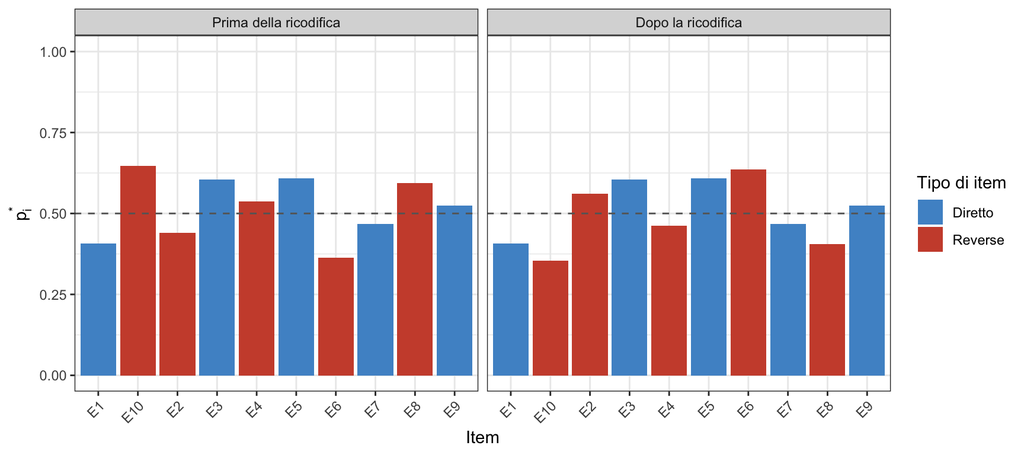

Difficoltà degli item di Estroversione prima e dopo la ricodifica

```r
df_pstar <- data.frame(
  Item     = rep(E, 2),
  p_star   = c(p_star_orig, p_star_rec),
  Versione = rep(c("Prima della ricodifica", "Dopo la ricodifica"), each = 10),
  Tipo     = rep(ifelse(E %in% Erev, "Reverse", "Diretto"), 2)
)
df_pstar$Versione <- factor(df_pstar$Versione,
                            levels = c("Prima della ricodifica", "Dopo la ricodifica"))

ggplot(df_pstar, aes(x = Item, y = p_star, fill = Tipo)) +
  geom_col() +
  geom_hline(yintercept = 0.5, linetype = "dashed", color = "gray40") +
  facet_wrap(~Versione) +
  scale_fill_manual(values = c("Diretto" = "steelblue3", "Reverse" = "tomato3")) +
  labs(x = "Item", y = expression(p[i]^"*"), fill = "Tipo di item") +
  ylim(0, 1) +
  theme_bw() +
  theme(axis.text.x = element_text(angle = 45, hjust = 1))
```

Dopo la ricodifica tutti gli item sono nella stessa direzione e i valori di $p_i^*$ diventano comparabili.

**Codice**

```r
# tabella riassuntiva della difficoltà dopo la ricodifica
p_star_tab <- data.frame(
  Item   = names(p_star_rec),
  Media  = round(colMeans(itemE, na.rm = TRUE), 2),
  p_star = round(p_star_rec, 2),
  Tipo   = ifelse(names(p_star_rec) %in% Erev, "Reverse (ricodificato)", "Diretto")
)
p_star_tab
```

```
    Item Media p_star                   Tipo
E1    E1  2.63   0.41                Diretto
E2    E2  3.24   0.56 Reverse (ricodificato)
E3    E3  3.42   0.60                Diretto
E4    E4  2.85   0.46 Reverse (ricodificato)
E5    E5  3.43   0.61                Diretto
E6    E6  3.55   0.64 Reverse (ricodificato)
E7    E7  2.87   0.47                Diretto
E8    E8  2.62   0.41 Reverse (ricodificato)
E9    E9  3.09   0.52                Diretto
E10  E10  2.41   0.35 Reverse (ricodificato)
```